# NDVI trend fjell

## Libraries needed

```r
library(tidyverse)
library(dplyr)
library(broom)
library(sf)
library(RColorBrewer)
library("gridExtra")
library(ggridges)
library(ggplot2)
```

## Data

NDVI samples NDVI sample locations ØT fjell regions

ndviTS is a simple tibble with the variables ID, year and NDVI

```r
ndviTS
```

```
## # A tibble: 500,140 x 3
##        ID  year  ndvi
##     <dbl> <dbl> <dbl>
##  1  15136  2000 0.523
##  2 968635  2000 0.201
##  3 548872  2000 0.505
##  4 338936  2000 0.479
##  5 561107  2000 0.458
##  6 155082  2000 0.603
##  7 752490  2000 0.530
##  8  52722  2000 0.552
##  9 750123  2000 0.677
## 10  87444  2000 0.332
## # ... with 500,130 more rows
```

locations is a spatial object with the same ID’s as in ndviTS and the corresponding point geometry

```r
locations
```

```
## Simple feature collection with 29658 features and 1 field
## Geometry type: POINT
## Dimension:     XY
## Bounding box:  xmin: 4.673168 ymin: 58.33117 xmax: 31.07896 ymax: 71.16132
## Geodetic CRS:  WGS 84
## First 10 features:
##        ID                  geometry
## 1   15136 POINT (5.840641 60.54294)
## 2  968635   POINT (9.07951 62.6231)
## 3  548872 POINT (6.631273 59.14986)
## 4  338936 POINT (25.33822 69.99437)
## 5  561107 POINT (8.053704 62.51785)
## 6  155082 POINT (27.23629 70.93837)
## 7  830356 POINT (8.257126 61.62694)
## 8  202160 POINT (7.356875 60.72745)
## 9  752490 POINT (7.071486 59.22123)
## 10  52722 POINT (9.457698 62.86394)
```

regions is a spatial object with a polygon geometry for the regions in ØT fjell

```r
regions
```

```
## Simple feature collection with 5 features and 2 fields
## Geometry type: POLYGON
## Dimension:     XY
## Bounding box:  xmin: 4.087524 ymin: 57.75901 xmax: 31.76159 ymax: 71.38488
## Geodetic CRS:  WGS 84
##   id            region                       geometry
## 1  1        Nord-Norge POLYGON ((11.88023 65.06874...
## 2  2        Midt-Norge POLYGON ((8.205852 62.33174...
## 3  3 Ãstlandet POLYGON ((10.5931 58.76096,...
## 4  4        Vestlandet POLYGON ((6.470577 58.29951...
## 5  5        SÃ¸rlandet POLYGON ((9.067269 58.25027...
```

## Analysis

we run a linear model (ndvi~year) for every sample in ndviTS, and for every sample where years have been randomized

```r
# calculate linear regressions for each pixel
ndviTrends <- ndviTS  %>%
  group_by(ID) %>%
  nest()%>%
  mutate(model = map(data, ~lm(ndvi ~ year, data = .x))) %>%
  mutate(tidy = map(model, tidy),
           glance = map(model, glance),
           augment = map(model, augment),
           rsq = glance %>% map_dbl('r.squared'),
           pvalue = glance %>% map_dbl('p.value'),
           intercept = tidy %>% map_dbl(~ filter(.x, term == "(Intercept)") %>% pull(estimate)),
           slope = tidy %>% map_dbl(~ filter(.x, term == "year") %>% pull(estimate))) %>%
  dplyr::select(ID, intercept, slope, rsq, pvalue)

ndviTrends

# randomize years and calculate linear regressions
ndviTrends_ran <- ndviTS %>%
  group_by(ID) %>%
  mutate(year_ran = sample(year,20)) %>%
  nest()%>%
  mutate(model = map(data, ~lm(ndvi ~ year_ran, data = .x))) %>%
  mutate(tidy = map(model, tidy),
         glance = map(model, glance),
         augment = map(model, augment),
         rsq = glance %>% map_dbl('r.squared'),
         pvalue = glance %>% map_dbl('p.value'),
         intercept = tidy %>% map_dbl(~ filter(.x, term == "(Intercept)") %>% pull(estimate)),
         slope = tidy %>% map_dbl(~ filter(.x, term == "year_ran") %>% pull(estimate))) %>%
  dplyr::select(ID, intercept, slope, rsq, pvalue)
```

```r
ndviTrends
```

```
## # A tibble: 25,007 x 5
## # Groups:   ID [25,007]
##        ID intercept    slope      rsq   pvalue
##     <dbl>     <dbl>    <dbl>    <dbl>    <dbl>
##  1  15136   -1.96   0.00125  0.138    0.107
##  2 968635   -9.26   0.00476  0.254    0.0235
##  3 548872    0.318  0.000108 0.000668 0.914
##  4 338936   -3.33   0.00191  0.170    0.0706
##  5 561107   -6.29   0.00340  0.526    0.000297
##  6 155082   -3.64   0.00214  0.156    0.0845
##  7 752490    0.0860 0.000226 0.00467  0.775
##  8  52722   -0.268  0.000449 0.00383  0.795
##  9 750123   -3.08   0.00187  0.151    0.0905
## 10  87444   -1.79   0.00107  0.132    0.116
## # ... with 24,997 more rows
```

```r
ndviTrends_ran
```

```
## # A tibble: 25,007 x 5
## # Groups:   ID [25,007]
##        ID intercept     slope     rsq pvalue
##     <dbl>     <dbl>     <dbl>   <dbl>  <dbl>
##  1  15136    -0.160  0.000357 0.0112   0.657
##  2 968635     2.50  -0.00109  0.0133   0.629
##  3 548872    -0.732  0.000631 0.0226   0.527
##  4 338936    -1.84   0.00117  0.0635   0.284
##  5 561107    -1.89   0.00120  0.0661   0.274
##  6 155082     1.38  -0.000353 0.00425  0.785
##  7 752490     1.49  -0.000474 0.0204   0.548
##  8  52722     5.81  -0.00257  0.126    0.125
##  9 750123     1.45  -0.000385 0.00640  0.737
## 10  87444     1.89  -0.000759 0.0657   0.275
## # ... with 24,997 more rows
```

We can plot the slopes as histograms (original=blue, randomized=red)

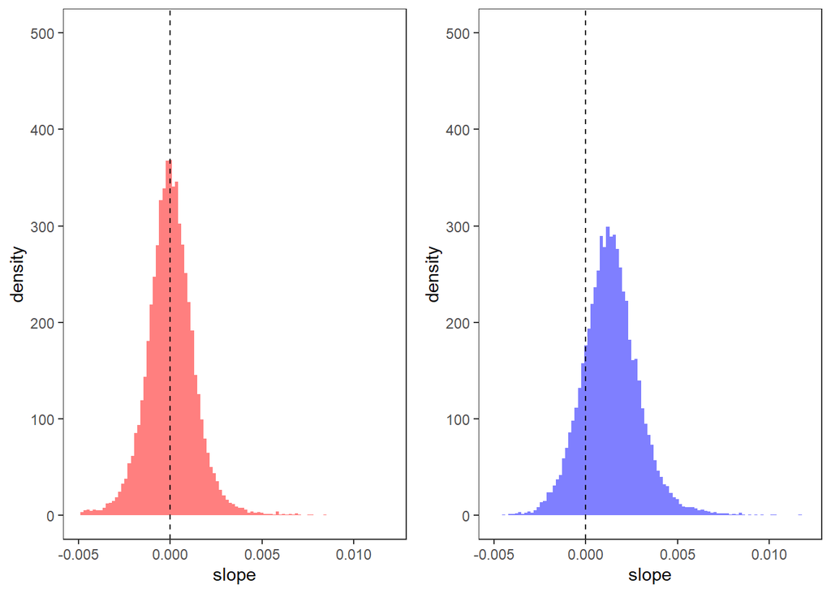

Original: Most slopes are clearly positive, fewer are negative. Randomized: Slopes are centered around zero and with similar variability. We derive the 0.025 and 0.975 quantiles from the ‘randomized’ slopes to define the limit values for good ecological condition under the reference condition.

```r
# derive quantiles
ndviTrend_percent_ran <- ndviTrends_ran %>% ungroup() %>%
  summarise(t_025 = quantile(slope,0.025)[[1]],
            t_975 = quantile(slope,0.975)[[1]])
```

On the very left we see the result of this operation with the scaling values on the ‘randomized’ slopes To the right we see the original slopes with the same scaling and limit values

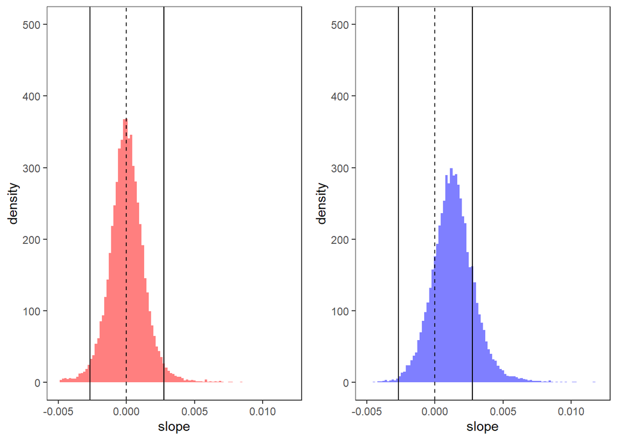

## Scaling

We define the scaling as well as the scaled values and create NDVI indices. Note that we scale twice: - the values lower than the reference value against the lower limit value and the minimum value - the values larger than the reference value against the upper limit value and the maximum value

```r
# scaling values
ref <- 0
lim.l <- as.numeric(ndviTrend_percent_ran[1])
lim.u <- as.numeric(ndviTrend_percent_ran[2])
maxmin.l <- as.numeric(ndviTrends_ran %>% ungroup() %>%
  summarise(min(slope)))
maxmin.u <- as.numeric(ndviTrends_ran %>% ungroup() %>%
  summarise(max(slope)))

# scaled values
r.s <- 1    # reference value
l.s <- 0.6  # limit value
a.s <- 0    # abscence of indicator, or indicator at maximum

ndviTrends2 <- ndviTrends
# scaling against upper limit
ndviTrends2$ndvi.index.u <- ifelse(ndviTrends2$slope>lim.u,
                                   ( l.s - (l.s * (ndviTrends2$slope - lim.u) / (maxmin.u - lim.u) ) ),
                                   ( r.s - ( (r.s - l.s) * (ndviTrends2$slope - ref) / (lim.u - ref) ) )
)
ndviTrends2$ndvi.index.u[ndviTrends2$ndvi.index.u > 1] <- NA
ndviTrends2$ndvi.index.u[ndviTrends2$ndvi.index.u < 0] <- 0
# scaling to lower limit
ndviTrends2$ndvi.index.l <- ifelse(ndviTrends2$slope<lim.l,
                                   (a.s + (ndviTrends2$slope-maxmin.l) * ( (l.s-a.s) / (lim.l-maxmin.l) ) ),
                                   (l.s + (ndviTrends2$slope-lim.l) * ( (r.s-l.s) / (ref-lim.l) ) )
)
ndviTrends2$ndvi.index.l[ndviTrends2$ndvi.index.l > 1] <- NA
ndviTrends2$ndvi.index.l[ndviTrends2$ndvi.index.l < 0] <- 0

summary(ndviTrends2$ndvi.index.l)
```

```
##    Min. 1st Qu.  Median    Mean 3rd Qu.    Max.    NA's
##   0.237   0.821   0.903   0.874   0.959   1.000   20623
```

```r
summary(ndviTrends2$ndvi.index.u)
```

```
##    Min. 1st Qu.  Median    Mean 3rd Qu.    Max.    NA's
##   0.000   0.638   0.766   0.751   0.870   1.000    4384
```

Here is the result, the dashed line indicates the limit for good ecological condition.

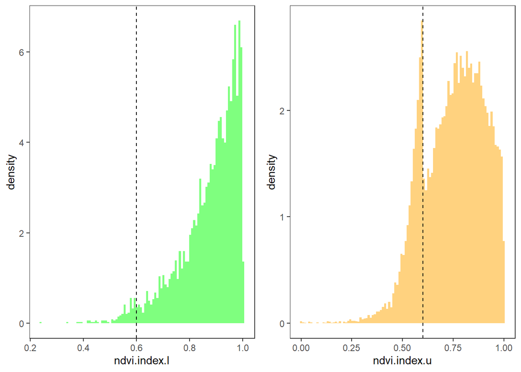

Finally, we merge the indices with the geometry and drop the geometry before bootstrapping the results.

```r
# join indices with region information
ndviTrends2 = left_join(locations,ndviTrends2, left=TRUE, by = "ID")
ndviTrends2 <- ndviTrends2[!is.na(ndviTrends2$slope),]
# getting region info into ndviTrends2
ndviTrends2 <- st_intersection(ndviTrends2, regions)
ndviTrends2 <- ndviTrends2 %>%
  rename(pixel.id = ID, region.id = id)

# drop geometry
ndviTrends3 <- st_drop_geometry(ndviTrends2)
head(ndviTrends3)
```

```
##    pixel.id  intercept        slope         rsq      pvalue ndvi.index.u
## 4    338936 -3.3287964 0.0019090229 0.170231568 0.070625234    0.7216162
## 6    155082 -3.6369720 0.0021428935 0.156267826 0.084507116    0.6875120
## 13    87444 -1.7918838 0.0010733833 0.131504470 0.116096517    0.8434736
## 14   644901 -0.7982837 0.0006624054 0.004363013 0.782025936    0.9034045
## 22   330612 -2.2286442 0.0013249250 0.270269270 0.018797425    0.8067925
## 23   354939 -2.6705059 0.0015783458 0.327426966 0.008378939    0.7698373
##    ndvi.index.l region.id     region
## 4            NA         1 Nord-Norge
## 6            NA         1 Nord-Norge
## 13           NA         1 Nord-Norge
## 14           NA         1 Nord-Norge
## 22           NA         1 Nord-Norge
## 23           NA         1 Nord-Norge
```

```r
summary(ndviTrends3)
```

```
##     pixel.id        intercept            slope                 rsq
##  Min.   :    11   Min.   :-37.7116   Min.   :-0.0101970   Min.   :0.00000
##  1st Qu.:248491   1st Qu.: -4.0272   1st Qu.: 0.0003741   1st Qu.:0.02281
##  Median :499595   Median : -2.1007   Median : 0.0013077   Median :0.09019
##  Mean   :499628   Mean   : -2.1904   Mean   : 0.0013580   Mean   :0.13985
##  3rd Qu.:751647   3rd Qu.: -0.1743   3rd Qu.: 0.0022576   3rd Qu.:0.21350
##  Max.   :999970   Max.   : 20.9098   Max.   : 0.0188948   Max.   :0.86562
##
##      pvalue         ndvi.index.u    ndvi.index.l     region.id
##  Min.   :0.00000   Min.   :0.000   Min.   :0.237   Min.   :1.000
##  1st Qu.:0.04026   1st Qu.:0.638   1st Qu.:0.821   1st Qu.:1.000
##  Median :0.19827   Median :0.765   Median :0.903   Median :2.000
##  Mean   :0.30522   Mean   :0.751   Mean   :0.874   Mean   :2.116
##  3rd Qu.:0.52504   3rd Qu.:0.870   3rd Qu.:0.959   3rd Qu.:3.000
##  Max.   :1.00000   Max.   :1.000   Max.   :1.000   Max.   :5.000
##                    NA's   :4383    NA's   :20610
##     region
##  Length:24993
##  Class :character
##  Mode  :character
##
##
##
##
```

```r
ndviTrends3$region <- as.factor(ndviTrends3$region)
levels(ndviTrends3$region)
```

```
## [1] "Ãstlandet" "Midt-Norge"      "Nord-Norge"      "SÃ¸rlandet"
## [5] "Vestlandet"
```

```r
levels(ndviTrends3$region)[c(1,4)] <- c("Austlandet","Soerlandet")
levels(ndviTrends3$region)
```

```
## [1] "Austlandet" "Midt-Norge" "Nord-Norge" "Soerlandet" "Vestlandet"
```

Here is a graphic representation of the slopes by region (for the original data, no ranomization of years)

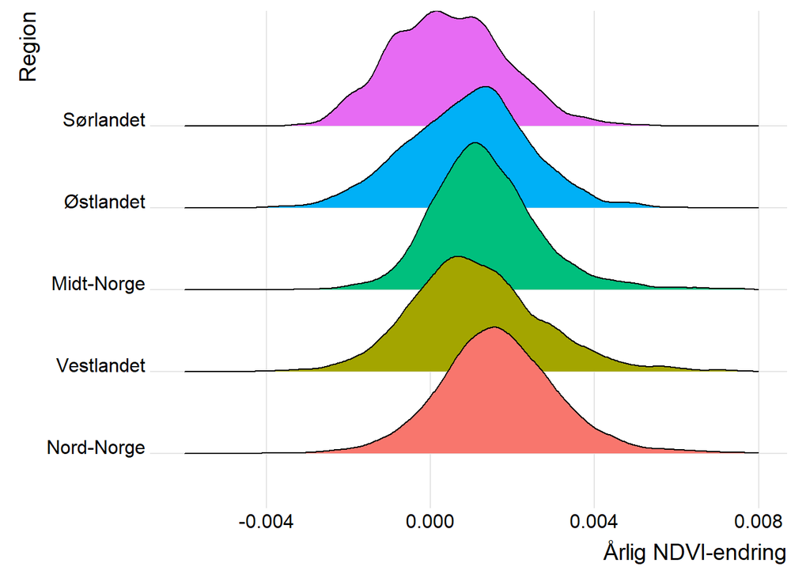

## Bootstrapping

```r
# Empty dataframes for bootstrapping results
ndvi.fjell.boot.tot <- data.frame(region = factor(),
                              slope = numeric(),
                              ndvi.index.l = numeric(),
                              ndvi.index.u = numeric()
                              )
ndvi.fjell.boot.N <- ndvi.fjell.boot.M <- ndvi.fjell.boot.A <- ndvi.fjell.boot.V <- ndvi.fjell.boot.S <- ndvi.fjell.boot.tot


# number of bootstraps
nsim <- 10



# Norge total bootstrap
for (k in 1:nsim){

  ### Sample data
  ## total
  temp.t <- ndviTrends3[sample(nrow(ndviTrends3), replace=T),]
  ## Nord-Norge (1)
  ndviTrends3.N <- ndviTrends3[ndviTrends3$region.id == 1,]
  temp.N <- ndviTrends3.N[sample(nrow(ndviTrends3.N), replace=T),]
  ## Midt-Norge (2)
  ndviTrends3.M <- ndviTrends3[ndviTrends3$region.id == 2,]
  temp.M <- ndviTrends3.M[sample(nrow(ndviTrends3.M), replace=T),]
  ## Østlandet (3)
  ndviTrends3.A <- ndviTrends3[ndviTrends3$region.id == 3,]
  temp.A <- ndviTrends3.A[sample(nrow(ndviTrends3.A), replace=T),]
  ## Vestlandet (4)
  ndviTrends3.V <- ndviTrends3[ndviTrends3$region.id == 4,]
  temp.V <- ndviTrends3.V[sample(nrow(ndviTrends3.V), replace=T),]
  # Sørlandet (5)
  ndviTrends3.S <- ndviTrends3[ndviTrends3$region.id == 5,]
  temp.S <- ndviTrends3.S[sample(nrow(ndviTrends3.S), replace=T),]

  ### Estimates
  ## Norge total
  # Mean values
  ndvi.fjell.boot.tot[k,"slope"] <- mean(temp.t$slope,na.rm=T)
  ndvi.fjell.boot.tot[k,"ndvi.index.l"] <- mean(temp.t$ndvi.index.l,na.rm=T)
  ndvi.fjell.boot.tot[k,"ndvi.index.u"] <- mean(temp.t$ndvi.index.u,na.rm=T)

  ## Nord-Norge (N)
  # Mean values
  ndvi.fjell.boot.N[k,"slope"] <- mean(temp.N$slope,na.rm=T)
  ndvi.fjell.boot.N[k,"ndvi.index.l"] <- mean(temp.N$ndvi.index.l,na.rm=T)
  ndvi.fjell.boot.N[k,"ndvi.index.u"] <- mean(temp.N$ndvi.index.u,na.rm=T)

  ## Midt-Norge (M)
  # Mean values
  ndvi.fjell.boot.M[k,"slope"] <- mean(temp.M$slope,na.rm=T)
  ndvi.fjell.boot.M[k,"ndvi.index.l"] <- mean(temp.M$ndvi.index.l,na.rm=T)
  ndvi.fjell.boot.M[k,"ndvi.index.u"] <- mean(temp.M$ndvi.index.u,na.rm=T)

  ## Østlandet (A)
  # Mean values
  ndvi.fjell.boot.A[k,"slope"] <- mean(temp.A$slope,na.rm=T)
  ndvi.fjell.boot.A[k,"ndvi.index.l"] <- mean(temp.A$ndvi.index.l,na.rm=T)
  ndvi.fjell.boot.A[k,"ndvi.index.u"] <- mean(temp.A$ndvi.index.u,na.rm=T)

  ## Vestlandet (V)
  # Mean values
  ndvi.fjell.boot.V[k,"slope"] <- mean(temp.V$slope,na.rm=T)
  ndvi.fjell.boot.V[k,"ndvi.index.l"] <- mean(temp.V$ndvi.index.l,na.rm=T)
  ndvi.fjell.boot.V[k,"ndvi.index.u"] <- mean(temp.V$ndvi.index.u,na.rm=T)

  ## Sørlandet (S)
  # Mean values
  ndvi.fjell.boot.S[k,"slope"] <- mean(temp.S$slope,na.rm=T)
  ndvi.fjell.boot.S[k,"ndvi.index.l"] <- mean(temp.S$ndvi.index.l,na.rm=T)
  ndvi.fjell.boot.S[k,"ndvi.index.u"] <- mean(temp.S$ndvi.index.u,na.rm=T)

}

ndvi.fjell.boot.tot$region <- "t"
ndvi.fjell.boot.N$region <- "N"
ndvi.fjell.boot.M$region <- "M"
ndvi.fjell.boot.A$region <- "A"
ndvi.fjell.boot.V$region <- "V"
ndvi.fjell.boot.S$region <- "S"
```

## Results

```r
# Norge total
summary(ndvi.fjell.boot.tot)[,c(3,4)]
```

```
##   ndvi.index.l     ndvi.index.u
##  Min.   :0.8717   Min.   :0.7482
##  1st Qu.:0.8723   1st Qu.:0.7498
##  Median :0.8730   Median :0.7508
##  Mean   :0.8732   Mean   :0.7507
##  3rd Qu.:0.8737   3rd Qu.:0.7511
##  Max.   :0.8764   Max.   :0.7529
```

```r
# Nord Norge
summary(ndvi.fjell.boot.N)[,c(3,4)]
```

```
##   ndvi.index.l     ndvi.index.u
##  Min.   :0.8744   Min.   :0.7278
##  1st Qu.:0.8790   1st Qu.:0.7297
##  Median :0.8814   Median :0.7305
##  Mean   :0.8811   Mean   :0.7301
##  3rd Qu.:0.8832   3rd Qu.:0.7311
##  Max.   :0.8874   Max.   :0.7314
```

```r
# Midt-Norge
summary(ndvi.fjell.boot.M)[,c(3,4)]
```

```
##   ndvi.index.l     ndvi.index.u
##  Min.   :0.9007   Min.   :0.7699
##  1st Qu.:0.9040   1st Qu.:0.7703
##  Median :0.9054   Median :0.7722
##  Mean   :0.9057   Mean   :0.7725
##  3rd Qu.:0.9079   3rd Qu.:0.7737
##  Max.   :0.9093   Max.   :0.7778
```

```r
# Østlandet
summary(ndvi.fjell.boot.A)[,c(3,4)]
```

```
##   ndvi.index.l     ndvi.index.u
##  Min.   :0.8501   Min.   :0.7706
##  1st Qu.:0.8532   1st Qu.:0.7755
##  Median :0.8547   Median :0.7764
##  Mean   :0.8558   Mean   :0.7763
##  3rd Qu.:0.8584   3rd Qu.:0.7779
##  Max.   :0.8638   Max.   :0.7792
```

```r
# Vestlandet
summary(ndvi.fjell.boot.V)[,c(3,4)]
```

```
##   ndvi.index.l     ndvi.index.u
##  Min.   :0.8650   Min.   :0.7576
##  1st Qu.:0.8707   1st Qu.:0.7624
##  Median :0.8740   Median :0.7652
##  Mean   :0.8735   Mean   :0.7647
##  3rd Qu.:0.8756   3rd Qu.:0.7668
##  Max.   :0.8821   Max.   :0.7707
```

```r
# Sørlandet
summary(ndvi.fjell.boot.S)[,c(3,4)]
```

```
##   ndvi.index.l     ndvi.index.u
##  Min.   :0.8474   Min.   :0.8081
##  1st Qu.:0.8576   1st Qu.:0.8115
##  Median :0.8587   Median :0.8142
##  Mean   :0.8592   Mean   :0.8138
##  3rd Qu.:0.8639   3rd Qu.:0.8147
##  Max.   :0.8659   Max.   :0.8207
```

The lower and upper indicators for NDVI should have a joint weight of 1 in the assessment of ecological condition. Both indicators should thus receive a weight directly dependent of the number of pixels they represent. This may vary between regions and compared to the entire country.

```r
# number of pixels for lower and upper indicator - by region
# lower
ndviTrends3 %>%
  group_by(region) %>%
  drop_na(ndvi.index.l) %>%
  summarise(no_rows = length(ndvi.index.l))
```

```
## # A tibble: 5 x 2
##   region     no_rows
##   <fct>        <int>
## 1 Austlandet    1031
## 2 Midt-Norge     516
## 3 Nord-Norge    1432
## 4 Soerlandet     605
## 5 Vestlandet     799
```

```r
# upper
ndviTrends3 %>%
  group_by(region) %>%
  drop_na(ndvi.index.u) %>%
  summarise(no_rows = length(ndvi.index.u))
```

```
## # A tibble: 5 x 2
##   region     no_rows
##   <fct>        <int>
## 1 Austlandet    2812
## 2 Midt-Norge    3288
## 3 Nord-Norge   10969
## 4 Soerlandet     958
## 5 Vestlandet    2583
```

```r
# number of pixels for lower and upper indicator - Norge total
# lower
nrow(ndviTrends2[!is.na(ndviTrends3$ndvi.index.l),])
```

```
## [1] 4383
```

```r
# upper
nrow(ndviTrends2[!is.na(ndviTrends3$ndvi.index.u),])
```

```
## [1] 20610
```

```r
# e.g. weights for lower and upper indicator - Norge total
# lower
nrow(ndviTrends2[!is.na(ndviTrends2$ndvi.index.l),])/
  (nrow(ndviTrends2[!is.na(ndviTrends2$ndvi.index.l),])+
     nrow(ndviTrends2[!is.na(ndviTrends2$ndvi.index.u),]))
```

```
## [1] 0.1753691
```

```r
# upper
nrow(ndviTrends2[!is.na(ndviTrends2$ndvi.index.u),])/
  (nrow(ndviTrends2[!is.na(ndviTrends2$ndvi.index.l),])+
     nrow(ndviTrends2[!is.na(ndviTrends2$ndvi.index.u),]))
```

```
## [1] 0.8246309
```

Klikk here to see the next steps of the analysis, aggregation and standardization of the indicator dataset.